Saltar al contenido principal

# Pipeline de datos: de la ENA a la muestra de modelado

Acceso a crédito de pequeños y medianos productores agropecuarios del Perú (ENA 2016–2025)

Autor/a

Roberth Carlos Gonzales Mauricio

Fecha de publicación

20 de noviembre de 2026

**Ver código: librerías y lectura de datos**

```r
suppressPackageStartupMessages({
  library(tidyverse)
  library(nanoparquet)
  library(knitr)
})

# Rutas relativas a esta carpeta (R/): los datos están en ../data
d <- read_parquet("../data/etapas/09_muestra_modelo.parquet") |> as_tibble()
dic <- read_csv("../data/diccionario_variables.csv", show_col_types = FALSE)
sel <- read_csv("resultados/03_variables.csv", show_col_types = FALSE)

DEPARTAMENTOS <- c("01" = "Amazonas", "02" = "Áncash", "03" = "Apurímac", "04" = "Arequipa", "05" = "Ayacucho",
  "06" = "Cajamarca", "07" = "Callao", "08" = "Cusco", "09" = "Huancavelica", "10" = "Huánuco", "11" = "Ica",
  "12" = "Junín", "13" = "La Libertad", "14" = "Lambayeque", "15" = "Lima", "16" = "Loreto", "17" = "Madre de Dios",
  "18" = "Moquegua", "19" = "Pasco", "20" = "Piura", "21" = "Puno", "22" = "San Martín", "23" = "Tacna",
  "24" = "Tumbes", "25" = "Ucayali")
d <- d |> mutate(
  REGION_TXT = factor(REGION, 1:3, c("Costa", "Sierra", "Selva")),
  DEP_TXT = DEPARTAMENTOS[sprintf("%02d", as.integer(DEPARTAMENTO))]
)

AZUL <- "#0072B2"; NARANJA <- "#D55E00"; GRIS <- "#6B7280"
COL_REGION <- c(Costa = "#D55E00", Sierra = "#004D40", Selva = "#56B4E9")
tema <- theme_minimal(base_size = 12) +
  theme(panel.grid.minor = element_blank(), plot.title = element_text(face = "bold"),
        plot.title.position = "plot", legend.position = "top")
miles <- function(x) format(x, big.mark = ",", scientific = FALSE, trim = TRUE)
pct <- function(x, k = 1) sprintf(paste0("%.", k, "f %%"), 100 * x)
```

## 1 Resumen

Este documento explica cómo se construyó, a partir de los microdatos de la Encuesta Nacional Agropecuaria (ENA) del INEI, el conjunto de datos con el que se entrena el modelo de acceso a crédito, y describe ese conjunto.

| Registros originales procesados | 6,288,812 filas (2014–2025) |
| --- | --- |
| Productores después de unir y filtrar | 217,535 |
| Productores después de la limpieza | 196,566 (sin ningún dato faltante) |
| **Muestra de modelado** | **49,837 productores, 44 columnas** |
| Con acceso a crédito | 5,937 (11.9 %) |
| Entrenamiento / prueba | 39,868 / 9,969 |

La unidad de análisis es **un productor en un año de encuesta**. La variable objetivo, `ACCESO_CREDITO`, vale 1 si el productor solicitó y obtuvo un crédito en los últimos 12 meses, y 0 si no lo solicitó o se lo denegaron.

## 2 Fuente de datos

La ENA es una encuesta anual del Instituto Nacional de Estadística e Informática (INEI) a productores agropecuarios. Sus microdatos son públicos en https://proyectos.inei.gob.pe/microdatos/. Se usaron dos entregas:

- **ENA 2014–2024:** un archivo SPSS consolidado de 3,843,598 filas y 1,679 variables (14.7 GB).
- **ENA 2025:** 21 módulos con 30 tablas CSV y 2,445,214 filas.

En ambas entregas cada fila corresponde a un registro de un capítulo del cuestionario (un cultivo, una parcela, un miembro del hogar, una especie animal). Por eso un mismo productor aparece en muchas filas, y el primer trabajo del pipeline es llevarlo a una sola.

### 2.1 Años incluidos

Tabla 1: Años de la ENA y motivo de inclusión o exclusión

| Año | En el modelo | Motivo |
| --- | --- | --- |
| 2014, 2015 | No | No registran superficie en hectáreas, años de experiencia ni número de parcelas |
| 2016, 2017 | Sí | Diseño por conglomerados |
| 2018 | No | Igual que 2014 y 2015: sin superficie en hectáreas |
| 2019 | Sí | Diseño por conglomerados |
| 2020 | No | La encuesta no se realizó (pandemia) |
| 2021 | No | No tiene el capítulo de crédito; trae en su lugar un módulo COVID |
| 2022 | Sí | Diseño por conglomerados |
| 2023, 2024, 2025 | Sí | Nuevo diseño: marco de áreas |

## 3 El pipeline paso a paso

**Ver código**

```
flowchart TD
    A["ENA 2014–2024<br/>3,843,598 filas · 1,679 variables"] --> C
    B["ENA 2025<br/>30 tablas · 2,445,214 filas"] --> C
    C["1–2 · Conversión y carga<br/>6,288,812 filas apiladas"] --> D
    D["3 · Una fila por productor y año<br/>341,211 × 1,026"] --> E
    E["4 · Filtros, variable objetivo<br/>y 35 predictores<br/>217,535 productores"] --> F
    F["5 · Limpieza con 8 reglas<br/>196,566 · sin faltantes"] --> G
    G["6 · Muestra estratificada<br/>por año × región y conglomerado<br/>49,837 productores"] --> H
    H["7 · Partición fija por conglomerado"] --> I["Entrenamiento<br/>39,868"]
    H --> J["Prueba<br/>9,969"]
```

```
flowchart TD
    A["ENA 2014–2024<br/>3,843,598 filas · 1,679 variables"] --> C
    B["ENA 2025<br/>30 tablas · 2,445,214 filas"] --> C
    C["1–2 · Conversión y carga<br/>6,288,812 filas apiladas"] --> D
    D["3 · Una fila por productor y año<br/>341,211 × 1,026"] --> E
    E["4 · Filtros, variable objetivo<br/>y 35 predictores<br/>217,535 productores"] --> F
    F["5 · Limpieza con 8 reglas<br/>196,566 · sin faltantes"] --> G
    G["6 · Muestra estratificada<br/>por año × región y conglomerado<br/>49,837 productores"] --> H
    H["7 · Partición fija por conglomerado"] --> I["Entrenamiento<br/>39,868"]
    H --> J["Prueba<br/>9,969"]
```

Figura 1: Flujo de los datos desde los microdatos del INEI hasta la muestra de modelado

Los pasos 1 a 7 se ejecutaron una sola vez sobre los microdatos completos, que ocupan unos 50 GB y no caben en este repositorio. Sus conteos provienen del registro de procesamiento. Este repositorio parte del resultado del paso 7, el archivo `data/etapas/09_muestra_modelo.parquet`.

### 3.1 Pasos 1 y 2 · Conversión y carga

- El archivo SPSS 2014–2024 se leyó por bloques de 200,000 filas y se guardó en formato Parquet, un archivo por año (283 MB en total). Los valores perdidos de SPSS se convirtieron en vacíos.
- Las 30 tablas de 2025 se cargaron en una base de datos analítica y se apilaron. De sus 1,329 columnas, 1,324 tienen el mismo nombre que en 2014–2024, lo que permitió unir ambas entregas.
- Se descartó una versión CSV de 2014–2024 de 35 GB porque estaba incompleta (solo tenía el 26 % de las filas).

### 3.2 Paso 3 · Una fila por productor y año

- **Llave del productor:** en 2014–2022 es conglomerado + número de vivienda + unidad agropecuaria; desde 2023 es segmento + identificador del productor + unidad agropecuaria. Este cambio responde al cambio de diseño muestral del INEI en 2023.
- **Variables de una sola respuesta** (edad, sexo, asociado…): se toma su valor único.
- **Variables de varias filas** (cultivos, parcelas, animales): se resumen en conteos y porcentajes, como el número de cultivos o el porcentaje de cultivos con riego.
- **Productores sin cuestionario principal:** se excluyeron 45,286 llaves. En 2021 había 41,700 registros sueltos de derivados agrícolas que no enlazaban con ningún productor.
- **Resultado:** 341,211 productores-año con 1,026 variables.

### 3.3 Paso 4 · Población de estudio y variables

Tabla 2: Filtros que definen la población de estudio

| Paso | Productores | Quitados | Motivo |
| --- | --- | --- | --- |
| Base productor-año 2014–2025 | 341,211 |  |  |
| Encuesta completa (RESFIN = 1) | 340,804 | 407 | Entrevistas incompletas |
| Años 2016, 2017, 2019, 2022–2025 | 228,310 | 112,494 | Ver la tabla de años |
| Respondió la pregunta de crédito | 224,782 | 3,528 | Sin respuesta en P901 |
| Pequeños y medianos (CODIGO = 1) | 217,535 | 7,247 | Grandes productores y empresas: otra población |

**Variable objetivo.** `ACCESO_CREDITO` = 1 si respondió “sí” a la pregunta P901 (solicitó crédito) y “sí” a la P902 (lo obtuvo).

**Predictores.** Se construyeron 35 variables candidatas en ocho grupos: productor, hogar, tierra, tecnología y riego, mercado, pecuario, servicios y contexto. Las características personales (edad, sexo, educación, lengua) se toman del miembro del hogar registrado como productor.

**Control de fuga de información.** Se excluyó todo el capítulo 900 (fuente, monto y uso del crédito), porque solo existe para quien ya obtuvo crédito y revelaría la respuesta al modelo.

**Decisiones de construcción:**

- La superficie se toma solo de las variables ya convertidas a hectáreas, porque las demás están en unidades locales (yugadas, topos).
- Los montos en soles (arriendo, pago de agua, pago de asistencia técnica) se convirtieron a sí/no, porque la inflación del periodo los hace poco comparables.
- `TIENE_PECUARIO` cuenta solo las especies con animales: el cuestionario registra una fila por especie aunque el productor no la tenga.

### 3.4 Paso 5 · Limpieza

Las reglas se aplicaron en orden. No se imputó ningún valor: se descartaron los registros incoherentes o incompletos.

Tabla 3: Reglas de limpieza y registros eliminados

| Código | Regla | Eliminados | Con crédito | Quedan |
| --- | --- | --- | --- | --- |
| — | Población de estudio | 0 | 0 | 217,535 |
| L1 | Edad menor de 18 o mayor de 100 años | 15 | 0 | 217,520 |
| L2 | Experiencia mayor que edad − 10 | 1,644 | 145 | 215,876 |
| L3 | Superficie total faltante | 1,385 | 89 | 214,491 |
| L4 | Superficie total mayor de 500 ha | 273 | 34 | 214,218 |
| L5 | Superficie cosechada mayor que 3 × superficie total | 140 | 35 | 214,078 |
| L6 | Sin cultivos cosechados ni animales | 9,685 | 446 | 204,393 |
| L7 | Tres o más predictores faltantes | 2,980 | 252 | 201,413 |
| T1 | % de cultivos con riego = 0 si no tiene cultivos (corrección, no elimina) | 0 | 0 | 201,413 |
| L8 | Cualquier faltante restante | 4,847 | 341 | 196,566 |

### 3.5 Paso 6 · Muestra estratificada

Para trabajar con un tamaño manejable se tomó una muestra de unos 50,000 productores de la base limpia:

- **Estratos:** año × región natural (21 estratos), con asignación proporcional a su tamaño.
- **Unidad de muestreo:** el conglomerado completo. Así, los vecinos quedan siempre juntos y la validación agrupada sigue siendo válida.
- **Peso:** `FACTOR_EXP_MUESTRA` = `FACTOR_EXP` × (productores expandidos del estrato limpio / productores expandidos de la muestra en el estrato). Con este peso, la muestra representa a la población.

Tabla 4: La muestra reproduce a la población limpia (valores ponderados)

| Indicador | Población limpia (196,566) | Muestra (49,837) |
| --- | --- | --- |
| Acceso a crédito | 10.10 % | 10.13 % |
| Productores de la Sierra | 58.4 % | 58.5 % |
| Edad media (años) | 54.96 | 54.92 |
| Productoras mujeres | 26.7 % | 26.5 % |
| Asociados | 7.3 % | 7.2 % |
| Con asistencia técnica | 5.7 % | 5.5 % |
| Venden cultivos | 70.2 % | 70.3 % |

### 3.6 Paso 7 · Partición en entrenamiento y prueba

La columna `CONJUNTO` fija qué productores son de entrenamiento (80 %) y cuáles de prueba (20 %). La partición se hizo por conglomerado y estratificada por la variable objetivo. Todo el análisis posterior (selección de variables, ajuste de hiperparámetros, umbral) usa solo el entrenamiento; la prueba se usa una vez, al final.

## 4 El conjunto de datos resultante

### 4.1 Estructura

**Ver código**

```r
roles <- dic |> select(variable, tipo, grupo, descripcion, fuente_ena) |>
  bind_rows(tibble(variable = c("ESTRATO", "FACTOR_EXP_MUESTRA", "CONJUNTO"),
                   tipo = c("id", "peso", "id"), grupo = "diseño",
                   descripcion = c("Estrato de muestreo: año × región natural",
                                   "Factor de expansión ajustado a la muestra",
                                   "Partición fija: entrenamiento o prueba"),
                   fuente_ena = "derivada"))
stopifnot(setequal(roles$variable, names(d |> select(-REGION_TXT, -DEP_TXT))))
conteo <- roles |> mutate(rol = case_when(grupo == "diseño" ~ "Diseño y pesos",
                                          tipo == "objetivo" ~ "Variable objetivo",
                                          TRUE ~ "Predictor candidato")) |> count(rol)
```

El archivo tiene **49,837 filas y 44 columnas**: 35 predictores candidatos, 1 variable objetivo y 8 columnas de diseño muestral y pesos, que no entran al modelo.

### 4.2 Controles de calidad

**Ver código**

```r
compartidos <- length(intersect(d$GRUPO_CV[d$CONJUNTO == "entrenamiento"],
                                d$GRUPO_CV[d$CONJUNTO == "prueba"]))
tibble(
  Control = c("Valores faltantes en todo el archivo",
              "Productores repetidos en un mismo año",
              "Conglomerados presentes en entrenamiento y prueba a la vez",
              "Variable objetivo solo con valores 0 y 1",
              "Edad entre 18 y 100 años",
              "Superficie total entre 0 y 500 ha"),
  Resultado = c(miles(sum(is.na(d))),
                miles(sum(duplicated(d[c("ANIO", "K_PROD")]))),
                miles(compartidos),
                ifelse(all(d$ACCESO_CREDITO %in% 0:1), "Sí", "No"),
                ifelse(all(between(d$EDAD, 18, 100)), "Sí", "No"),
                ifelse(all(between(d$SUP_TOTAL_HA, 0, 500)), "Sí", "No"))
)
```

Tabla 5: Controles de calidad sobre el archivo final

| Control | Resultado |
| --- | --- |
| Valores faltantes en todo el archivo | 0 |
| Productores repetidos en un mismo año | 0 |
| Conglomerados presentes en entrenamiento y prueba a la vez | 0 |
| Variable objetivo solo con valores 0 y 1 | Sí |
| Edad entre 18 y 100 años | Sí |
| Superficie total entre 0 y 500 ha | Sí |

### 4.3 Diccionario de variables

**Ver código**

```r
roles |>
  mutate(`En el modelo final` = ifelse(variable %in% sel$variable[sel$seleccionada == 1], "Sí", "")) |>
  select(Variable = variable, Grupo = grupo, Tipo = tipo, Descripción = descripcion,
         `Fuente ENA` = fuente_ena, `En el modelo final`)
```

Tabla 6: Diccionario del conjunto de datos (fuente: preguntas del cuestionario ENA)

| Variable | Grupo | Tipo | Descripción | Fuente ENA | En el modelo final |
| --- | --- | --- | --- | --- | --- |
| ANIO | diseño | id | Año de la encuesta | ANIO |  |
| K_PROD | diseño | id | Llave del productor dentro del año | derivada |  |
| GRUPO_CV | diseño | id | Conglomerado/segmento: grupo para validación cruzada agrupada | CONGLOMERADO / NSEGM |  |
| FACTOR_EXP | diseño | peso | Factor de expansión del productor | FACTOR / FACTOR_PRODUCTOR |  |
| DISENO | diseño | id | Diseño muestral (conglomerados ≤2022, marco de áreas ≥2023) | derivada |  |
| ACCESO_CREDITO | objetivo | objetivo | Solicitó y obtuvo crédito en los últimos 12 meses | P901, P902 |  |
| EDAD | productor | numérica | Edad del productor (años) | P1104_A (P1102 = productor) | Sí |
| SEXO_MUJER | productor | binaria | Productora mujer | P1103 (P1102 = productor) |  |
| EDUCACION | productor | ordinal | Nivel educativo 1=sin nivel … 10=superior univ. completa | P1105 (P1102 = productor) | Sí |
| LENGUA_NATIVA | productor | binaria | Lengua materna quechua, aymara u otra nativa | P1106 (P1102 = productor) |  |
| EXPERIENCIA | productor | numérica | Años dedicado a la actividad agropecuaria | P101 |  |
| TAM_HOGAR | hogar | numérica | Nº de miembros del hogar del productor | cap. 1100 (conteo) | Sí |
| VIVE_EN_PARCELA | hogar | binaria | Vive en alguna de sus parcelas | P1110 |  |
| SUP_TOTAL_HA | tierra | numérica | Superficie total de sus parcelas (ha) | P104_SUP_ha | Sí |
| N_PARCELAS | tierra | numérica | Nº de parcelas trabajadas en el distrito (cambia de definición en 2023) | P103 |  |
| SUP_COSECHADA_HA | tierra | numérica | Superficie cosechada total (ha) | P217_SUP_ha (suma por cultivo) | Sí |
| N_CULTIVOS | tierra | numérica | Nº de cultivos cosechados | cap. 200AB (conteo) |  |
| ARRIENDA_TIERRA | tierra | binaria | Pagó arrendamiento de tierras | P1001A_1 > 0 | Sí |
| PCT_CULTIVOS_RIEGO | tecnología | numérica | % de cultivos con riego (no secano) | P212 por cultivo | Sí |
| RIEGO_TECNIFICADO | tecnología | binaria | Algún cultivo con riego tecnificado (goteo, aspersión, etc.) | P213 en 1–6 |  |
| PAGA_AGUA_RIEGO | tecnología | binaria | Pagó por agua de riego | P1001A_3 > 0 |  |
| USA_ABONOS | tecnología | binaria | Usa abonos | P301A_13 |  |
| USA_FERTILIZANTES | tecnología | binaria | Usa fertilizantes | P301A_14 | Sí |
| USA_PLAGUICIDAS | tecnología | binaria | Usa plaguicidas | P301A_15 | Sí |
| ANALISIS_SUELO | tecnología | binaria | Realiza análisis de suelo | P301A_1 |  |
| VENDE_CULTIVOS | mercado | binaria | Vendió parte de su producción agrícola | P220_1_CANT_1 > 0 |  |
| PCT_CULTIVOS_VENDIDOS | mercado | numérica | % de cultivos de los que vendió algo | P220_1_CANT_1 por cultivo | Sí |
| VENDE_AGROIND_EXTERIOR | mercado | binaria | Vendió a agroindustria o mercado exterior | P223_3, P223_4 |  |
| VENDE_LIMA_REGIONAL | mercado | binaria | Vendió a mercados regionales o de Lima | P223_2, P223_5 | Sí |
| CERTIFICACION | mercado | binaria | Productos con certificación de calidad | P608 |  |
| TIENE_PECUARIO | pecuario | binaria | Tuvo animales en los últimos 12 meses | P402A/P404A > 0 (cap. 400A_1) |  |
| N_ESPECIES_PECUARIAS | pecuario | numérica | Nº de especies pecuarias que tuvo (vacunos, ovinos, cuyes, aves…) | P401A con P402A/P404A > 0 |  |
| ASOCIADO | servicios | binaria | Pertenece a asociación, cooperativa o comité | P801 | Sí |
| COMISION_REGANTES | servicios | binaria | Usuario de comisión/junta de regantes | P810 |  |
| CAPACITACION | servicios | binaria | Recibió capacitación (últimos 3 años) | P701 |  |
| ASISTENCIA_TECNICA | servicios | binaria | Recibió asistencia técnica (últimos 3 años) | P704 |  |
| PAGA_ASISTENCIA_TEC | servicios | binaria | Pagó por asistencia técnica agrícola | P1001A_4 > 0 |  |
| USA_INFO_PRECIOS | servicios | binaria | Usó información de precios de venta | P707_1 |  |
| REGION | contexto | categórica | Región natural 1=Costa 2=Sierra 3=Selva | REGION | Sí |
| DEPARTAMENTO | contexto | categórica | Código de departamento | CCDD | Sí |
| MINERIA_CERCA | contexto | binaria | Minas en explotación cerca de sus cultivos/animales | P603 |  |
| ESTRATO | diseño | id | Estrato de muestreo: año × región natural | derivada |  |
| FACTOR_EXP_MUESTRA | diseño | peso | Factor de expansión ajustado a la muestra | derivada |  |
| CONJUNTO | diseño | id | Partición fija: entrenamiento o prueba | derivada |  |

### 4.4 Distribución por año y región

**Ver código**

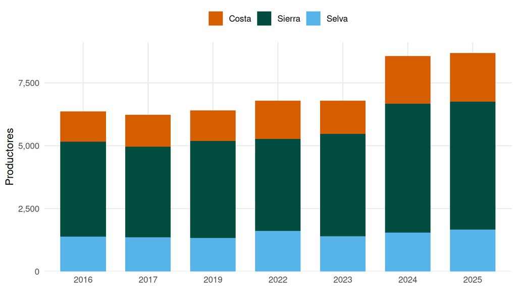

Figura 2: Productores de la muestra por año y región natural

```r
d |> count(ANIO, REGION_TXT) |>
  ggplot(aes(factor(ANIO), n, fill = REGION_TXT)) +
  geom_col(width = 0.7) +
  scale_fill_manual(values = COL_REGION, name = NULL) +
  scale_y_continuous(labels = miles, expand = expansion(mult = c(0, 0.05))) +
  labs(x = NULL, y = "Productores") + tema
```

El tamaño de la muestra sube desde 2024 porque el INEI amplió la encuesta. Desde 2023 cambia el diseño muestral (de conglomerados a marco de áreas), lo que se registra en la columna `DISENO`.

### 4.5 Variable objetivo

**Ver código**

```r
tasa <- function(g) d |> group_by({{ g }}) |>
  summarise(Productores = n(), `Con crédito` = sum(ACCESO_CREDITO),
            `% muestra` = mean(ACCESO_CREDITO),
            `% ponderado` = weighted.mean(ACCESO_CREDITO, FACTOR_EXP_MUESTRA), .groups = "drop")
total <- d |> summarise(Productores = n(), `Con crédito` = sum(ACCESO_CREDITO), `% muestra` = mean(ACCESO_CREDITO),
                        `% ponderado` = weighted.mean(ACCESO_CREDITO, FACTOR_EXP_MUESTRA))
bind_rows(tasa(ANIO) |> mutate(ANIO = as.character(ANIO)), total |> mutate(ANIO = "Total")) |>
  mutate(across(c(Productores, `Con crédito`), miles), across(starts_with("%"), pct)) |>
  rename(Año = ANIO)
```

Tabla 7: Acceso a crédito por año (sin ponderar y ponderado)

| Año | Productores | Con crédito | % muestra | % ponderado |
| --- | --- | --- | --- | --- |
| 2016 | 6,362 | 965 | 15.2 % | 13.0 % |
| 2017 | 6,235 | 800 | 12.8 % | 11.6 % |
| 2019 | 6,408 | 651 | 10.2 % | 9.6 % |
| 2022 | 6,788 | 662 | 9.8 % | 8.3 % |
| 2023 | 6,795 | 787 | 11.6 % | 11.0 % |
| 2024 | 8,568 | 1,051 | 12.3 % | 8.8 % |
| 2025 | 8,681 | 1,021 | 11.8 % | 8.8 % |
| Total | 49,837 | 5,937 | 11.9 % | 10.1 % |

Solo 11.9 % de la muestra tiene crédito: hay unos 7.4 productores sin crédito por cada uno con crédito. Este desbalance explica por qué el modelo se evalúa con el área bajo la curva precisión-sensibilidad (AUC-PR) y no solo con la exactitud.

**Ver código**

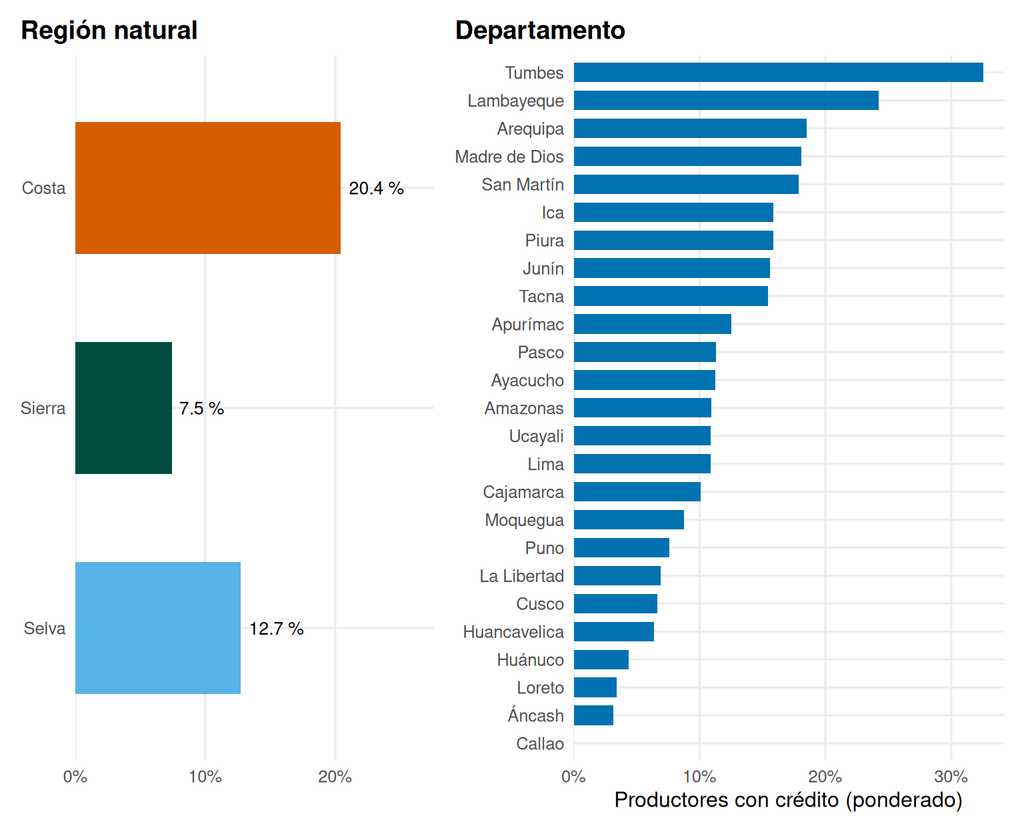

Figura 3: Acceso a crédito ponderado por región natural y por departamento

```r
p_reg <- tasa(REGION_TXT) |>
  ggplot(aes(`% ponderado`, fct_rev(REGION_TXT), fill = REGION_TXT)) +
  geom_col(width = 0.6, show.legend = FALSE) +
  geom_text(aes(label = pct(`% ponderado`)), hjust = -0.15, size = 3.5) +
  scale_fill_manual(values = COL_REGION) +
  scale_x_continuous(labels = scales::percent, expand = expansion(mult = c(0, 0.35))) +
  labs(x = NULL, y = NULL, title = "Región natural") + tema
p_dep <- tasa(DEP_TXT) |>
  ggplot(aes(`% ponderado`, fct_reorder(DEP_TXT, `% ponderado`))) +
  geom_col(fill = AZUL, width = 0.7) +
  scale_x_continuous(labels = scales::percent, expand = expansion(mult = c(0, 0.05))) +
  labs(x = "Productores con crédito (ponderado)", y = NULL, title = "Departamento") + tema
patchwork::wrap_plots(p_reg, p_dep, ncol = 2, widths = c(1, 1.2))
```

### 4.6 Predictores numéricos

**Ver código**

```r
num <- dic |> filter(tipo %in% c("numérica", "ordinal")) |> pull(variable)
d |> select(all_of(num)) |>
  pivot_longer(everything(), names_to = "Variable") |>
  group_by(Variable) |>
  summarise(Mínimo = min(value), P25 = quantile(value, 0.25), Mediana = median(value),
            Media = mean(value), P75 = quantile(value, 0.75), Máximo = max(value)) |>
  left_join(dic |> select(Variable = variable, Descripción = descripcion), by = "Variable") |>
  relocate(Descripción, .after = Variable) |>
  mutate(across(where(is.numeric), \(x) round(x, 2)))
```

Tabla 8: Descriptivos de los predictores numéricos y ordinales

| Variable | Descripción | Mínimo | P25 | Mediana | Media | P75 | Máximo |
| --- | --- | --- | --- | --- | --- | --- | --- |
| EDAD | Edad del productor (años) | 18 | 44.00 | 55.00 | 54.92 | 65.00 | 99.0 |
| EDUCACION | Nivel educativo 1=sin nivel … 10=superior univ. completa | 1 | 3.00 | 4.00 | 4.51 | 6.00 | 10.0 |
| EXPERIENCIA | Años dedicado a la actividad agropecuaria | 0 | 15.00 | 25.00 | 27.08 | 39.00 | 86.0 |
| N_CULTIVOS | Nº de cultivos cosechados | 0 | 2.00 | 3.00 | 4.36 | 6.00 | 62.0 |
| N_ESPECIES_PECUARIAS | Nº de especies pecuarias que tuvo (vacunos, ovinos, cuyes, aves…) | 0 | 1.00 | 2.00 | 2.36 | 4.00 | 11.0 |
| N_PARCELAS | Nº de parcelas trabajadas en el distrito (cambia de definición en 2023) | 1 | 1.00 | 1.00 | 2.27 | 2.00 | 99.0 |
| PCT_CULTIVOS_RIEGO | % de cultivos con riego (no secano) | 0 | 0.00 | 0.33 | 0.47 | 1.00 | 1.0 |
| PCT_CULTIVOS_VENDIDOS | % de cultivos de los que vendió algo | 0 | 0.00 | 0.50 | 0.48 | 1.00 | 1.0 |
| SUP_COSECHADA_HA | Superficie cosechada total (ha) | 0 | 0.27 | 0.85 | 3.23 | 2.45 | 517.5 |
| SUP_TOTAL_HA | Superficie total de sus parcelas (ha) | 0 | 0.91 | 2.40 | 8.76 | 6.50 | 500.0 |
| TAM_HOGAR | Nº de miembros del hogar del productor | 1 | 2.00 | 3.00 | 3.10 | 4.00 | 19.0 |

La superficie tiene una distribución muy asimétrica: la mayoría de productores trabaja pocas hectáreas y unos pocos trabajan muchas. Los árboles de decisión del modelo no necesitan transformarla; la regresión logística usa su logaritmo.

### 4.7 Predictores binarios

**Ver código**

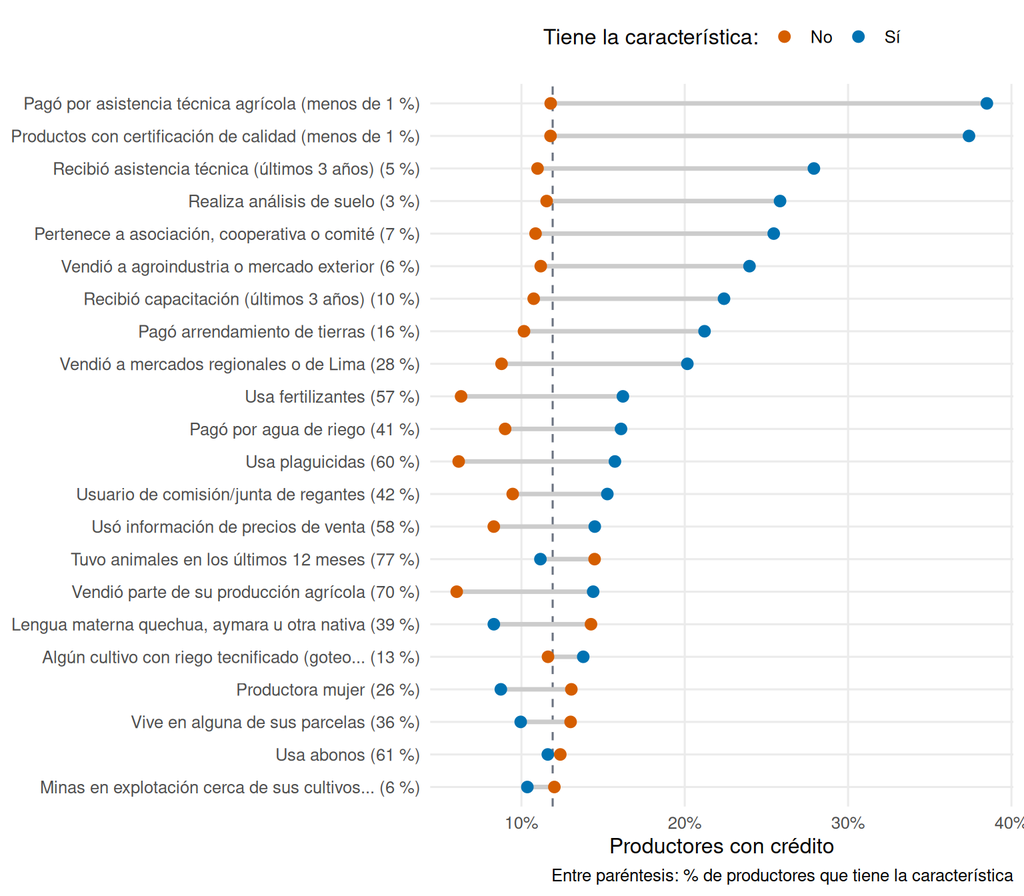

Figura 4: Acceso a crédito según cada predictor binario (sin ponderar). La línea gris es la tasa general.

```r
bin <- dic |> filter(tipo == "binaria") |> pull(variable)
etiq <- setNames(dic$descripcion, dic$variable)
tb <- d |> select(all_of(bin), ACCESO_CREDITO) |>
  pivot_longer(-ACCESO_CREDITO, names_to = "variable", values_to = "valor") |>
  group_by(variable) |>
  summarise(prevalencia = mean(valor),
            Sí = mean(ACCESO_CREDITO[valor == 1]), No = mean(ACCESO_CREDITO[valor == 0])) |>
  mutate(etiqueta = sprintf("%s (%s)", str_trunc(etiq[variable], 45),
                           ifelse(prevalencia < 0.01, "menos de 1 %", pct(prevalencia, 0))))
tb |> pivot_longer(c(Sí, No), names_to = "grupo", values_to = "tasa") |>
  ggplot(aes(tasa, fct_reorder(etiqueta, tasa, max), colour = grupo)) +
  geom_vline(xintercept = mean(d$ACCESO_CREDITO), colour = GRIS, linetype = 2) +
  geom_line(aes(group = etiqueta), colour = "grey80", linewidth = 1.2) +
  geom_point(size = 2.6) +
  scale_colour_manual(values = c(Sí = AZUL, No = NARANJA), name = "Tiene la característica:") +
  scale_x_continuous(labels = scales::percent) +
  labs(x = "Productores con crédito", y = NULL,
       caption = "Entre paréntesis: % de productores que tiene la característica") + tema
```

Las mayores diferencias aparecen en características poco frecuentes, como pagar asistencia técnica, tener certificación de calidad o hacer análisis de suelo, y en la pertenencia a una asociación, que tiene el 7 % de los productores. Son diferencias brutas: cada una mezcla el efecto de otras variables, como el tamaño de la finca. El modelo y SHAP separan esos efectos.

### 4.8 Correlación entre predictores

**Ver código**

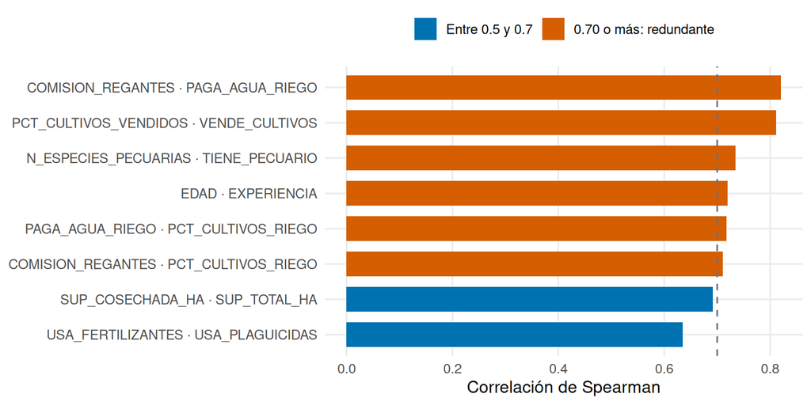

Figura 5: Pares de predictores con correlación de Spearman de 0.5 o más (en valor absoluto)

```r
pred <- dic |> filter(!grupo %in% c("diseño", "objetivo"), tipo != "categórica") |> pull(variable)
cm <- cor(d[pred], method = "spearman")
pares <- as_tibble(as.table(cm), .name_repair = "minimal") |>
  setNames(c("a", "b", "rho")) |>
  filter(as.character(a) < as.character(b), abs(rho) >= 0.5) |>
  arrange(desc(abs(rho))) |>
  mutate(par = paste(a, "·", b), redundante = abs(rho) >= 0.7)
ggplot(pares, aes(rho, fct_reorder(par, abs(rho)), fill = redundante)) +
  geom_col(width = 0.7) +
  geom_vline(xintercept = 0.7, linetype = 2, colour = GRIS) +
  scale_fill_manual(values = c(`TRUE` = NARANJA, `FALSE` = AZUL),
                    labels = c(`TRUE` = "0.70 o más: redundante", `FALSE` = "Entre 0.5 y 0.7"), name = NULL) +
  labs(x = "Correlación de Spearman", y = NULL) + tema
```

Los pares en naranja son redundantes. En la selección de variables, de cada uno se conservó el de mayor importancia SHAP.

### 4.9 Entrenamiento frente a prueba

**Ver código**

```r
d |> group_by(Conjunto = CONJUNTO) |>
  summarise(Productores = miles(n()), Conglomerados = miles(n_distinct(GRUPO_CV)),
            `% con crédito` = pct(mean(ACCESO_CREDITO)),
            `% Sierra` = pct(mean(REGION == 2)),
            `Edad media` = round(mean(EDAD), 1),
            `Sup. cosechada mediana (ha)` = round(median(SUP_COSECHADA_HA), 2),
            `% asociados` = pct(mean(ASOCIADO)))
```

Tabla 9: La partición mantiene la misma composición en entrenamiento y prueba

| Conjunto | Productores | Conglomerados | % con crédito | % Sierra | Edad media | Sup. cosechada mediana (ha) | % asociados |
| --- | --- | --- | --- | --- | --- | --- | --- |
| entrenamiento | 39,868 | 6,005 | 11.9 % | 58.7 % | 55.0 | 0.85 | 7.2 % |
| prueba | 9,969 | 1,486 | 11.9 % | 57.5 % | 54.6 | 0.88 | 6.9 % |

## 5 De los 35 candidatos a las 14 variables del modelo

La selección se hizo solo con el conjunto de entrenamiento, en tres pasos: importancia SHAP en validación cruzada agrupada, eliminación de redundantes (Spearman de 0.70 o más) y regla de un error estándar sobre la curva de AUC-PR según el número de variables.

**Ver código**

```r
sel |> mutate(Resultado = case_when(seleccionada == 1 ~ "Entra al modelo",
                                    str_detect(motivo, "redund") ~ "Fuera: redundante",
                                    TRUE ~ "Fuera: poca importancia")) |>
  select(Puesto = puesto, Variable = variable, Descripción = etiqueta,
         `Importancia SHAP` = shap, Resultado) |>
  mutate(`Importancia SHAP` = round(`Importancia SHAP`, 3))
```

Tabla 10: Resultado de la selección de variables (ordenadas por importancia SHAP)

| Puesto | Variable | Descripción | Importancia SHAP | Resultado |
| --- | --- | --- | --- | --- |
| 1 | SUP_COSECHADA_HA | Superficie cosechada (ha) | 0.462 | Entra al modelo |
| 2 | EDAD | Edad | 0.293 | Entra al modelo |
| 3 | DEPARTAMENTO | Departamento | 0.257 | Entra al modelo |
| 4 | TAM_HOGAR | Tamaño del hogar | 0.214 | Entra al modelo |
| 5 | USA_FERTILIZANTES | Usa fertilizantes | 0.201 | Entra al modelo |
| 6 | EDUCACION | Nivel educativo | 0.157 | Entra al modelo |
| 7 | USA_PLAGUICIDAS | Usa plaguicidas | 0.136 | Entra al modelo |
| 8 | REGION | Región natural | 0.121 | Entra al modelo |
| 9 | SUP_TOTAL_HA | Superficie total (ha) | 0.102 | Entra al modelo |
| 10 | VENDE_LIMA_REGIONAL | Vende a mercados regionales/Lima | 0.102 | Entra al modelo |
| 11 | PCT_CULTIVOS_RIEGO | % cultivos con riego | 0.099 | Entra al modelo |
| 12 | PCT_CULTIVOS_VENDIDOS | % cultivos vendidos | 0.094 | Entra al modelo |
| 13 | ASOCIADO | Asociado | 0.084 | Entra al modelo |
| 14 | ARRIENDA_TIERRA | Arrienda tierra | 0.082 | Entra al modelo |
| 15 | CAPACITACION | Recibió capacitación | 0.074 | Fuera: poca importancia |
| 16 | EXPERIENCIA | Años de experiencia | 0.069 | Fuera: redundante |
| 17 | PAGA_AGUA_RIEGO | Paga agua de riego | 0.063 | Fuera: redundante |
| 18 | N_PARCELAS | Nº de parcelas | 0.062 | Fuera: poca importancia |
| 19 | N_ESPECIES_PECUARIAS | Nº de especies pecuarias | 0.054 | Fuera: poca importancia |
| 20 | USA_INFO_PRECIOS | Usa información de precios | 0.046 | Fuera: poca importancia |
| 21 | LENGUA_NATIVA | Lengua materna nativa | 0.043 | Fuera: poca importancia |
| 22 | ASISTENCIA_TECNICA | Asistencia técnica | 0.042 | Fuera: poca importancia |
| 23 | N_CULTIVOS | Nº de cultivos | 0.038 | Fuera: poca importancia |
| 24 | COMISION_REGANTES | Comisión de regantes | 0.037 | Fuera: redundante |
| 25 | USA_ABONOS | Usa abonos | 0.026 | Fuera: poca importancia |
| 26 | VENDE_AGROIND_EXTERIOR | Vende a agroindustria/exterior | 0.013 | Fuera: poca importancia |
| 27 | VIVE_EN_PARCELA | Vive en la parcela | 0.012 | Fuera: poca importancia |
| 28 | SEXO_MUJER | Productora mujer | 0.011 | Fuera: poca importancia |
| 29 | ANALISIS_SUELO | Análisis de suelo | 0.010 | Fuera: poca importancia |
| 30 | RIEGO_TECNIFICADO | Riego tecnificado | 0.009 | Fuera: poca importancia |
| 31 | TIENE_PECUARIO | Tiene ganado | 0.009 | Fuera: redundante |
| 32 | VENDE_CULTIVOS | Vende cultivos | 0.005 | Fuera: redundante |
| 33 | MINERIA_CERCA | Minería cerca | 0.003 | Fuera: poca importancia |
| 34 | PAGA_ASISTENCIA_TEC | Paga asistencia técnica | 0.003 | Fuera: poca importancia |
| 35 | CERTIFICACION | Certificación de calidad | 0.002 | Fuera: poca importancia |

## 6 El conjunto de datos que entra al modelo

Esta sección describe el dataset final: lo que recibe XGBoost después de la selección de variables.

### 6.1 Del archivo de muestra a la matriz del modelo

**Ver código**

```
flowchart TD
    A["Muestra de modelado<br/>49,837 × 44 columnas"] --> B["Se apartan 8 columnas de diseño y pesos<br/>y la variable objetivo"]
    B --> C["35 predictores candidatos"]
    C --> D["Selección con el entrenamiento<br/>SHAP · Spearman ≥ 0.70 · regla de 1 EE"]
    D --> E["14 variables<br/>12 numéricas o binarias + 2 categóricas"]
    E --> F["Codificación 0/1 de las categóricas<br/>Región: 3 columnas · Departamento: 25"]
    F --> G["Matriz de 40 columnas"]
    G --> H["Entrenamiento<br/>39,868 × 40"]
    G --> I["Prueba<br/>9,969 × 40"]
    H --> J["XGBoost con caret<br/>CV de 5 grupos por conglomerado"]
    I --> K["Evaluación final<br/>una sola vez"]
```

```
flowchart TD
    A["Muestra de modelado<br/>49,837 × 44 columnas"] --> B["Se apartan 8 columnas de diseño y pesos<br/>y la variable objetivo"]
    B --> C["35 predictores candidatos"]
    C --> D["Selección con el entrenamiento<br/>SHAP · Spearman ≥ 0.70 · regla de 1 EE"]
    D --> E["14 variables<br/>12 numéricas o binarias + 2 categóricas"]
    E --> F["Codificación 0/1 de las categóricas<br/>Región: 3 columnas · Departamento: 25"]
    F --> G["Matriz de 40 columnas"]
    G --> H["Entrenamiento<br/>39,868 × 40"]
    G --> I["Prueba<br/>9,969 × 40"]
    H --> J["XGBoost con caret<br/>CV de 5 grupos por conglomerado"]
    I --> K["Evaluación final<br/>una sola vez"]
```

Figura 6: Cómo se arma la matriz del modelo a partir de la muestra

**Ver código**

```r
vars <- sel$variable[sel$seleccionada == 1]
dm <- d |> mutate(REGION = REGION_TXT, DEPARTAMENTO = factor(DEP_TXT))

# Misma codificación que matriz() en R/_comun.R: cada categoría pasa a una columna 0/1
matriz <- function(x, vars) {
  partes <- lapply(vars, function(v) {
    if (is.factor(x[[v]])) {
      m <- model.matrix(~ z - 1, data.frame(z = x[[v]]))
      colnames(m) <- paste0(v, "_", levels(x[[v]])); m
    } else matrix(as.numeric(x[[v]]), ncol = 1, dimnames = list(NULL, v))
  })
  do.call(cbind, partes)
}
tr <- dm |> filter(CONJUNTO == "entrenamiento")
te <- dm |> filter(CONJUNTO == "prueba")
X_tr <- matriz(tr, vars); X_te <- matriz(te, vars)
stopifnot(identical(colnames(X_tr), colnames(X_te)), !anyNA(X_tr), !anyNA(X_te))
```

**Ver código**

```r
tibble(
  Conjunto = c("Entrenamiento", "Prueba"),
  Filas = miles(c(nrow(X_tr), nrow(X_te))),
  Columnas = c(ncol(X_tr), ncol(X_te)),
  Conglomerados = miles(c(n_distinct(tr$GRUPO_CV), n_distinct(te$GRUPO_CV))),
  `Con crédito` = miles(c(sum(tr$ACCESO_CREDITO), sum(te$ACCESO_CREDITO))),
  `% con crédito` = pct(c(mean(tr$ACCESO_CREDITO), mean(te$ACCESO_CREDITO))),
  Uso = c("Ajuste de hiperparámetros, umbral y selección", "Evaluación final")
)
```

Tabla 11: Dimensiones del dataset que entra al modelo

| Conjunto | Filas | Columnas | Conglomerados | Con crédito | % con crédito | Uso |
| --- | --- | --- | --- | --- | --- | --- |
| Entrenamiento | 39,868 | 40 | 6,005 | 4,750 | 11.9 % | Ajuste de hiperparámetros, umbral y selección |
| Prueba | 9,969 | 40 | 1,486 | 1,187 | 11.9 % | Evaluación final |

**Qué no se hace a los datos antes del modelo:**

- **No se escalan ni se transforman** las variables numéricas: los árboles de decisión solo usan el orden de los valores.
- **No se imputan valores:** el archivo no tiene faltantes desde el paso 5.
- **No se balancean las clases** (ni sobremuestreo ni pesos por clase). El desbalance se trata con la métrica (AUC-PR) y con el umbral de decisión (0.175, el que maximiza F1 en la validación cruzada).
- **No se usan los factores de expansión** en el entrenamiento. Solo sirven para estimar tasas poblacionales.

### 6.2 Las 14 variables del modelo

**Ver código**

```r
resumen_var <- function(v) {
  x <- tr[[v]]; y <- tr$ACCESO_CREDITO
  tipo <- dic$tipo[dic$variable == v]
  if (is.factor(x)) {
    t <- tapply(y, x, mean)
    tibble(Variable = v, Tipo = tipo,
           Entra = sprintf("%d columnas 0/1", nlevels(x)),
           `Con crédito` = sprintf("Mayor tasa: %s (%s)", names(which.max(t)), pct(max(t))),
           `Sin crédito` = sprintf("Menor tasa: %s (%s)", names(which.min(t)), pct(min(t))))
  } else if (tipo == "binaria") {
    tibble(Variable = v, Tipo = tipo, Entra = "1 columna 0/1",
           `Con crédito` = pct(mean(x[y == 1])), `Sin crédito` = pct(mean(x[y == 0])))
  } else {
    f <- if (v %in% c("SUP_COSECHADA_HA", "SUP_TOTAL_HA")) median else mean
    nota <- if (identical(f, median)) " (mediana)" else ""
    tibble(Variable = v, Tipo = tipo, Entra = "1 columna numérica",
           `Con crédito` = paste0(round(f(x[y == 1]), 2), nota),
           `Sin crédito` = paste0(round(f(x[y == 0]), 2), nota))
  }
}
map_dfr(vars, resumen_var) |>
  left_join(sel |> select(Variable = variable, Descripción = etiqueta, Puesto = puesto), by = "Variable") |>
  select(Puesto, Variable, Descripción, Tipo, Entra, `Con crédito`, `Sin crédito`)
```

Tabla 12: Variables del modelo en el entrenamiento: valor medio según acceso a crédito. En las binarias el valor es el % de productores con la característica; en las categóricas se muestra la categoría con mayor tasa de crédito.

| Puesto | Variable | Descripción | Tipo | Entra | Con crédito | Sin crédito |
| --- | --- | --- | --- | --- | --- | --- |
| 1 | SUP_COSECHADA_HA | Superficie cosechada (ha) | numérica | 1 columna numérica | 2.3 (mediana) | 0.75 (mediana) |
| 2 | EDAD | Edad | numérica | 1 columna numérica | 50.89 | 55.57 |
| 3 | DEPARTAMENTO | Departamento | categórica | 25 columnas 0/1 | Mayor tasa: Tumbes (27.1 %) | Menor tasa: Callao (0.0 %) |
| 4 | TAM_HOGAR | Tamaño del hogar | numérica | 1 columna numérica | 3.46 | 3.05 |
| 5 | USA_FERTILIZANTES | Usa fertilizantes | binaria | 1 columna 0/1 | 76.3 % | 53.6 % |
| 6 | EDUCACION | Nivel educativo | ordinal | 1 columna numérica | 5.25 | 4.42 |
| 7 | USA_PLAGUICIDAS | Usa plaguicidas | binaria | 1 columna 0/1 | 78.9 % | 57.3 % |
| 8 | REGION | Región natural | categórica | 3 columnas 0/1 | Mayor tasa: Costa (21.1 %) | Menor tasa: Sierra (8.2 %) |
| 9 | SUP_TOTAL_HA | Superficie total (ha) | numérica | 1 columna numérica | 4.12 (mediana) | 2.16 (mediana) |
| 10 | VENDE_LIMA_REGIONAL | Vende a mercados regionales/Lima | binaria | 1 columna 0/1 | 45.6 % | 25.0 % |
| 11 | PCT_CULTIVOS_RIEGO | % cultivos con riego | numérica | 1 columna numérica | 0.6 | 0.46 |
| 12 | PCT_CULTIVOS_VENDIDOS | % cultivos vendidos | numérica | 1 columna numérica | 0.62 | 0.46 |
| 13 | ASOCIADO | Asociado | binaria | 1 columna 0/1 | 15.4 % | 6.1 % |
| 14 | ARRIENDA_TIERRA | Arrienda tierra | binaria | 1 columna 0/1 | 27.6 % | 14.1 % |

Los productores con crédito cosechan más superficie, usan más fertilizantes y plaguicidas, venden más a mercados regionales o de Lima y están asociados con más frecuencia. Son comparaciones simples, sin controlar por las demás variables.

### 6.3 Vista de la matriz

Las primeras filas de la matriz de entrenamiento, tal como las recibe XGBoost (se muestran solo algunas de las 40 columnas):

**Ver código**

```r
cols <- c(vars[!vars %in% c("REGION", "DEPARTAMENTO")][1:6],
          grep("^REGION_", colnames(X_tr), value = TRUE),
          head(grep("^DEPARTAMENTO_", colnames(X_tr), value = TRUE), 3))
as_tibble(X_tr[1:6, cols]) |>
  mutate(ACCESO_CREDITO = tr$ACCESO_CREDITO[1:6], .before = 1) |>
  mutate(across(where(is.numeric), \(x) round(x, 2)))
```

Tabla 13: Primeras 6 filas de la matriz de entrenamiento (columnas seleccionadas)

| ACCESO_CREDITO | SUP_COSECHADA_HA | EDAD | TAM_HOGAR | USA_FERTILIZANTES | EDUCACION | USA_PLAGUICIDAS | REGION_Costa | REGION_Sierra | REGION_Selva | DEPARTAMENTO_Amazonas | DEPARTAMENTO_Áncash | DEPARTAMENTO_Apurímac |
| --- | --- | --- | --- | --- | --- | --- | --- | --- | --- | --- | --- | --- |
| 0 | 0.60 | 70 | 1 | 0 | 3 | 1 | 1 | 0 | 0 | 0 | 0 | 0 |
| 0 | 0.60 | 45 | 3 | 1 | 6 | 1 | 1 | 0 | 0 | 0 | 0 | 0 |
| 0 | 0.12 | 71 | 2 | 1 | 3 | 1 | 1 | 0 | 0 | 0 | 0 | 0 |
| 1 | 0.24 | 60 | 1 | 1 | 3 | 1 | 1 | 0 | 0 | 0 | 0 | 0 |
| 0 | 1.00 | 89 | 4 | 0 | 4 | 0 | 1 | 0 | 0 | 0 | 0 | 0 |
| 0 | 0.66 | 80 | 1 | 1 | 3 | 1 | 1 | 0 | 0 | 0 | 0 | 0 |

Columnas de la matriz (40): `SUP_COSECHADA_HA`, `EDAD`, `DEPARTAMENTO_Amazonas`, `DEPARTAMENTO_Áncash`, `DEPARTAMENTO_Apurímac`, `DEPARTAMENTO_Arequipa`, `DEPARTAMENTO_Ayacucho`, `DEPARTAMENTO_Cajamarca`, `DEPARTAMENTO_Callao`, `DEPARTAMENTO_Cusco`, `DEPARTAMENTO_Huancavelica`, `DEPARTAMENTO_Huánuco`, `DEPARTAMENTO_Ica`, `DEPARTAMENTO_Junín`, `DEPARTAMENTO_La Libertad`, `DEPARTAMENTO_Lambayeque`, `DEPARTAMENTO_Lima`, `DEPARTAMENTO_Loreto`, `DEPARTAMENTO_Madre de Dios`, `DEPARTAMENTO_Moquegua`, `DEPARTAMENTO_Pasco`, `DEPARTAMENTO_Piura`, `DEPARTAMENTO_Puno`, `DEPARTAMENTO_San Martín`, `DEPARTAMENTO_Tacna`, `DEPARTAMENTO_Tumbes`, `DEPARTAMENTO_Ucayali`, `TAM_HOGAR`, `USA_FERTILIZANTES`, `EDUCACION`, `USA_PLAGUICIDAS`, `REGION_Costa`, `REGION_Sierra`, `REGION_Selva`, `SUP_TOTAL_HA`, `VENDE_LIMA_REGIONAL`, `PCT_CULTIVOS_RIEGO`, `PCT_CULTIVOS_VENDIDOS`, `ASOCIADO`, `ARRIENDA_TIERRA`.

## 7 Advertencias para usar estos datos

- **Cambio de diseño en 2023.** Desde 2023 el INEI usa un marco de áreas en lugar de conglomerados. La superficie mediana casi se duplica (de unas 1.6 a 3.2 ha) y `N_PARCELAS` cambia de definición. Las comparaciones entre años deben tenerlo en cuenta.
- **Montos convertidos a sí/no.** Arriendo, pago de agua y pago de asistencia técnica indican si el productor pagó algo, no cuánto.
- **Sin imputación.** Los registros con datos faltantes se descartaron. La población limpia excluye, por ejemplo, a quienes no cosecharon ni tuvieron animales en el periodo.
- **Asociación, no causalidad.** Los datos son de encuesta (observacionales). Las relaciones entre predictores y crédito describen asociación.
- **Pesos.** Para estimar tasas de la población usa `FACTOR_EXP_MUESTRA`. El modelo se entrena sin pesos.

## 8 Cómo reproducir este documento

Requiere R (con tidyverse, nanoparquet, knitr, rmarkdown y patchwork) y [Quarto](https://quarto.org). Desde la carpeta raíz del repositorio:

```bash
quarto render R/pipeline_datos.qmd
```

El resultado es `R/pipeline_datos.html`, un archivo único que se abre en cualquier navegador.